# Adverse pregnancy outcomes analysis vaginal microbiome

Alexandra Jazmin Roth Schulze

2024-01-14

All the models for the microbiome were adjusted for SeqRun batch effect and mother ID as random effects and parity and BMI as fixed effects because we know from the literature that those have an important effect on the vaginal microbiome.

#Vaginal microbiome

##Premature delivery (PD)

###Description of samples used in this analysis

For analysing the vaginal microbiome of women who had premature deliveries vs. women who had term deliveries only women **with T1D** were considered due to the number of premature deliveries being too small (n=8) in women without T1D. There are a total of 148 samples distributed as follows:

| Var1 | Freq |
| --- | --- |
| Premature | 44 |
| Term | 104 |

Where:

Premature: < 37 weeks of gestation.

Term: > 37 weeks of gestation.

###Alpha diversity

glmer.nb was used for richness and invSimpson because the data distributes like a negative binomial and we have random factos [i.e. sequencing batch and motherid].

|  | Chisq | Df | Pr(>Chisq) |
| --- | --- | --- | --- |
| Parity | 0.0172937 | 1 | 0.8953754 |
| BMI_Cat | 3.9132124 | 3 | 0.2709894 |
| GAD | 0.2202190 | 1 | 0.6388731 |

|  | Chisq | Df | Pr(>Chisq) |
| --- | --- | --- | --- |
| Parity | 0.0000001 | 1 | 0.9997886 |
| GAD | 0.7171465 | 1 | 0.3970815 |
| BMI | 1.1336712 | 1 | 0.2869936 |
| Parity:GAD | 0.0278504 | 1 | 0.8674610 |
| GAD:BMI | 5.0790933 | 1 | 0.0242160 |

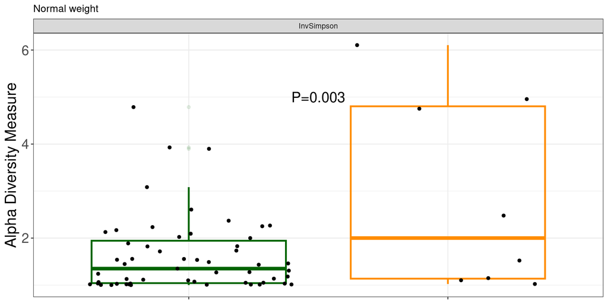

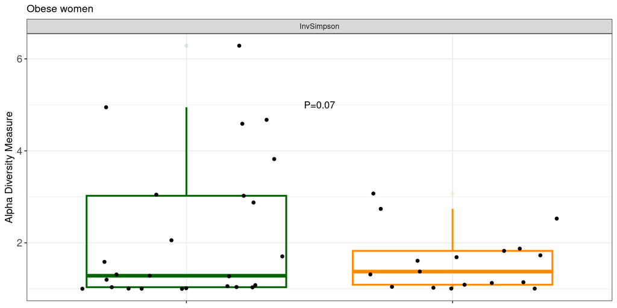

Analysis within each category of BMI was performed in R version 4.3.1 with the emmeans package (code shown in Rmd file)

###Differential abundance analysis

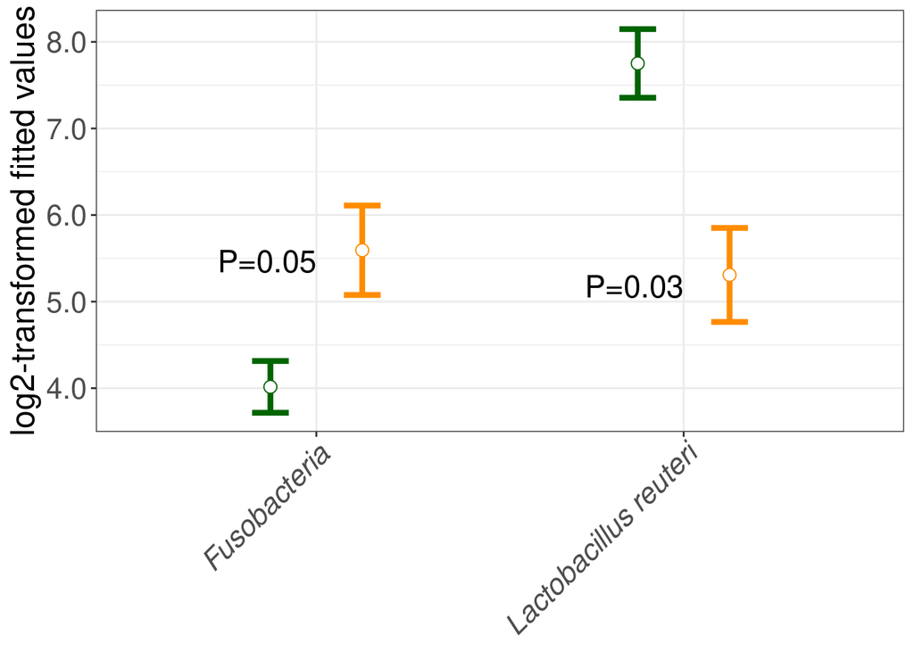

###Composed plots

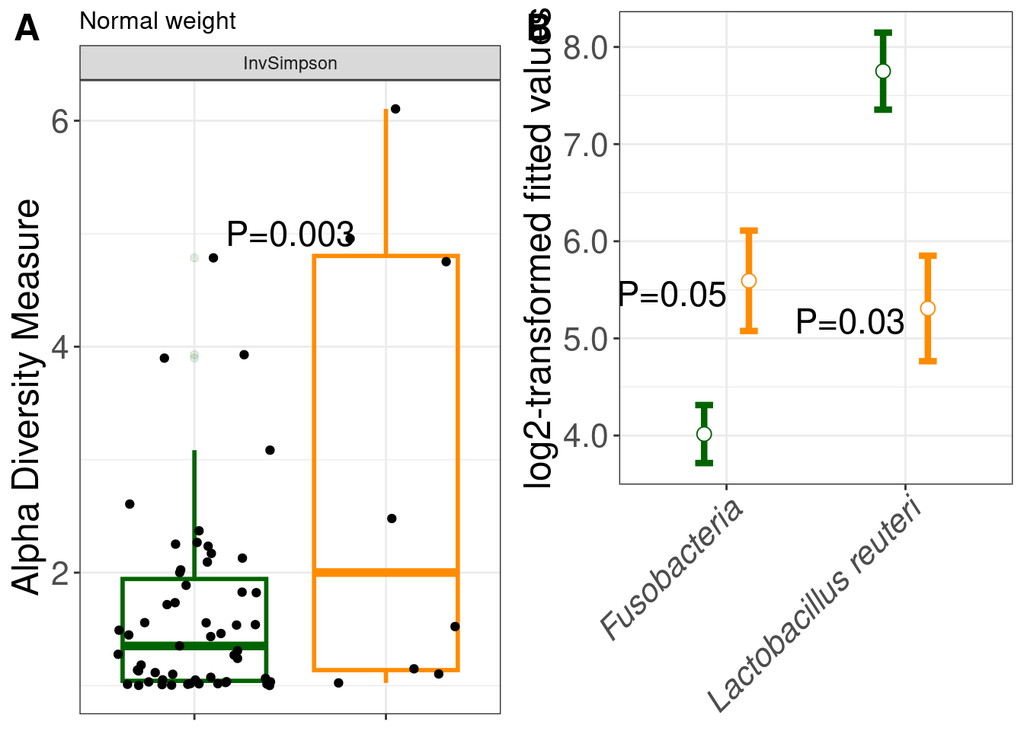

##Preeclampsia (PE)

###Description of samples used in this analysis

For analysing the vaginal microbiome of women who had or did not have preeclampsia there are a total of 158 samples for which we have the preeclampsia status. Only samples from women with T1D will be analysed as only women with T1D status had preeclampsia. The samples are distributed as follows:

|  | T1D |
| --- | --- |
| 0 | 129 |
| 1 | 29 |

Where:

0: women without preeclampsia and 1: women with preeclampsia.

###Alpha diversity

|  | Chisq | Df | Pr(>Chisq) |
| --- | --- | --- | --- |
| BMI_Cat | 5.5029623 | 3 | 0.1384615 |
| Any.PE | 0.0213042 | 1 | 0.8839534 |
| Parity | 0.0207441 | 1 | 0.8854782 |
| BMI_Cat:Any.PE | 2.9954317 | 2 | 0.2236404 |
| Any.PE:Parity | 0.0072055 | 1 | 0.9323526 |

|  | Chisq | Df | Pr(>Chisq) |
| --- | --- | --- | --- |
| Parity | 0.0813897 | 1 | 0.7754229 |
| Any.PE | 7.7098168 | 1 | 0.0054921 |
| BMI_Cat | 1.2901544 | 3 | 0.7314723 |
| Parity:Any.PE | 0.0131859 | 1 | 0.9085798 |
| Any.PE:BMI_Cat | 9.5829465 | 2 | 0.0083002 |

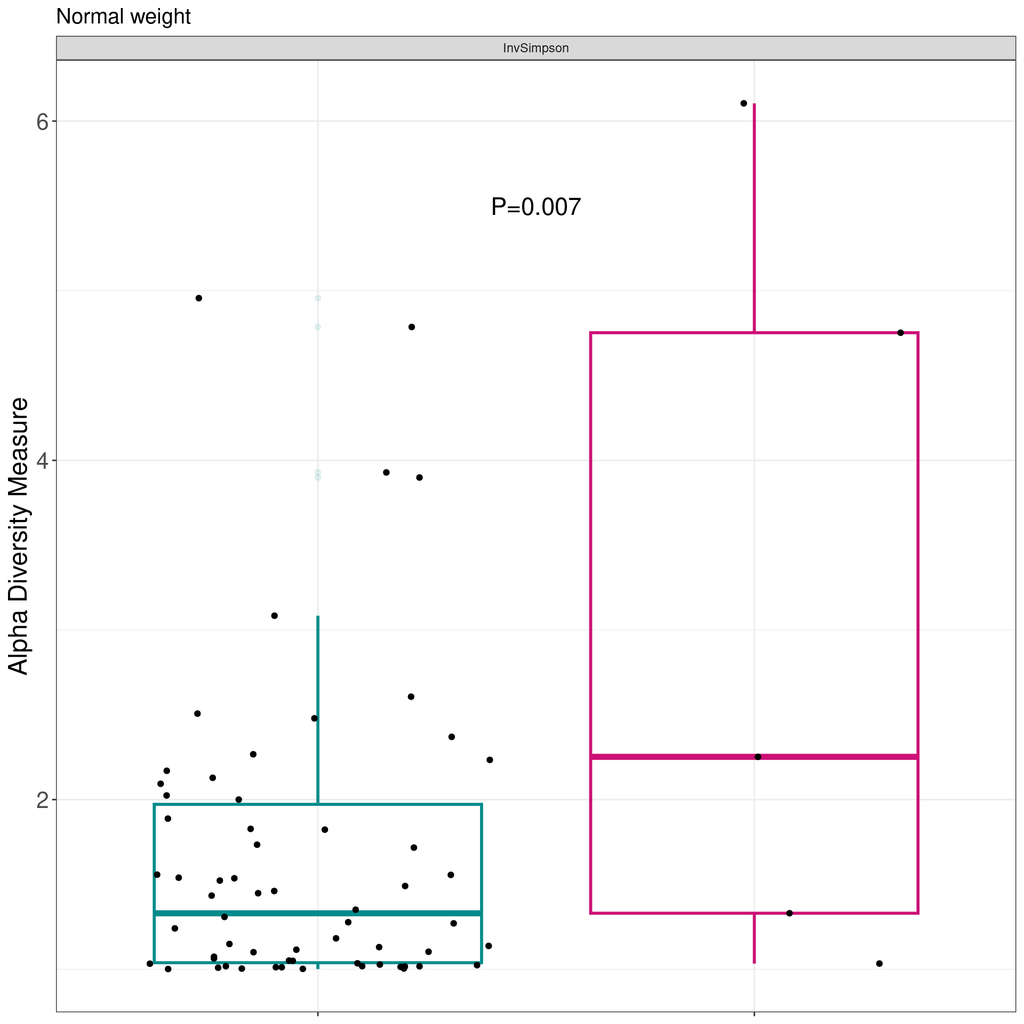

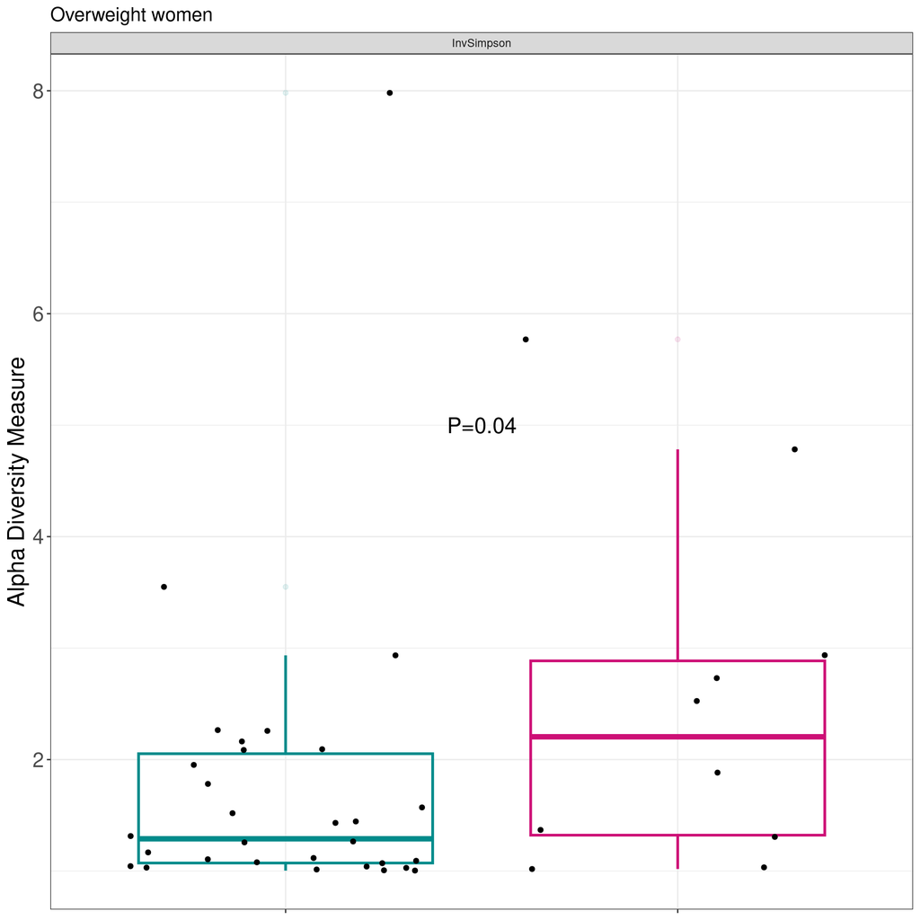

Analysis of contrast within each category of BMI was performed in R vaersion 4.3.1 using emmeans package (code shown in Rmd).

###Beta diversity

|  | Df | SumOfSqs | R2 | F | Pr(>F) |
| --- | --- | --- | --- | --- | --- |
| SeqRun | 1 | 0.4176738 | 0.0091965 | 1.4851397 | 0.856 |
| Parity | 1 | 2.1317823 | 0.0469382 | 7.5800644 | 0.066 |
| Any.PE | 1 | 0.2346243 | 0.0051660 | 0.8342632 | 0.276 |
| BMI | 1 | 0.3575164 | 0.0078719 | 1.2712354 | 0.373 |
| HLA | 2 | 0.6729560 | 0.0148173 | 1.1964283 | 0.081 |
| Parity:Any.PE | 1 | 0.4254805 | 0.0093683 | 1.5128982 | 0.134 |
| Any.PE:BMI | 1 | 0.3851132 | 0.0084795 | 1.3693626 | 0.172 |
| Any.PE:HLA | 2 | 0.5750056 | 0.0126606 | 1.0222854 | 0.112 |
| Residual | 143 | 40.2166603 | 0.8855016 | NA | NA |
| Total | 153 | 45.4168125 | 1.0000000 | NA | NA |

|  | Df | SumOfSqs | R2 | F | Pr(>F) |
| --- | --- | --- | --- | --- | --- |
| SeqRun | 1 | 0.0946908 | 0.0051189 | 0.8229484 | 0.033 |
| Parity | 1 | 0.2969856 | 0.0160548 | 2.5810736 | 0.009 |
| Any.PE | 1 | 0.2046556 | 0.0110635 | 1.7786420 | 0.266 |
| BMI | 1 | 0.1256029 | 0.0067900 | 1.0916031 | 0.745 |
| HLA | 2 | 0.5910513 | 0.0319517 | 2.5683854 | 0.451 |
| Parity:Any.PE | 1 | 0.2690268 | 0.0145433 | 2.3380861 | 0.325 |
| Any.PE:BMI | 1 | 0.1375963 | 0.0074383 | 1.1958361 | 0.029 |
| Any.PE:HLA | 2 | 0.3246806 | 0.0175519 | 1.4108843 | 0.134 |
| Residual | 143 | 16.4539830 | 0.8894875 | NA | NA |
| Total | 153 | 18.4982728 | 1.0000000 | NA | NA |

|  | Df | SumOfSqs | R2 | F | Pr(>F) |
| --- | --- | --- | --- | --- | --- |
| SeqRun | 1 | 0.0707563 | 0.0042512 | 0.6942441 | 0.137 |
| Parity | 1 | 0.3981293 | 0.0239208 | 3.9063491 | 0.010 |
| Any.PE | 1 | 0.2315953 | 0.0139149 | 2.2723573 | 0.275 |
| BMI | 1 | 0.1479321 | 0.0088882 | 1.4514744 | 0.521 |
| HLA | 2 | 0.6137330 | 0.0368749 | 3.0109003 | 0.521 |
| Parity:Any.PE | 1 | 0.2882662 | 0.0173199 | 2.8283993 | 0.407 |
| Any.PE:BMI | 1 | 0.0863487 | 0.0051881 | 0.8472323 | 0.050 |
| Any.PE:HLA | 2 | 0.2325459 | 0.0139720 | 1.1408424 | 0.777 |
| Residual | 143 | 14.5743474 | 0.8756699 | NA | NA |
| Total | 153 | 16.6436542 | 1.0000000 | NA | NA |

|  | Df | SumOfSqs | R2 | F | Pr(>F) |
| --- | --- | --- | --- | --- | --- |
| SeqRun | 1 | 0.0187743 | 0.0013033 | 0.2130705 | 0.009 |
| Parity | 1 | 0.3735554 | 0.0259327 | 4.2395037 | 0.031 |
| Any.PE | 1 | 0.2158631 | 0.0149855 | 2.4498434 | 0.274 |
| BMI | 1 | 0.1232071 | 0.0085532 | 1.3982846 | 0.501 |
| HLA | 2 | 0.5550548 | 0.0385326 | 3.1496759 | 0.659 |
| Parity:Any.PE | 1 | 0.2529439 | 0.0175597 | 2.8706759 | 0.393 |
| Any.PE:BMI | 1 | 0.0949825 | 0.0065938 | 1.0779624 | 0.056 |
| Any.PE:HLA | 2 | 0.1702691 | 0.0118203 | 0.9661975 | 0.752 |
| Residual | 143 | 12.6001594 | 0.8747189 | NA | NA |
| Total | 153 | 14.4048095 | 1.0000000 | NA | NA |

|  | Df | SumOfSqs | R2 | F | Pr(>F) |
| --- | --- | --- | --- | --- | --- |
| SeqRun | 1 | 0.0015342 | 0.0001755 | 0.0288420 | 0.133 |
| Parity | 1 | 0.2857046 | 0.0326833 | 5.3710631 | 0.033 |
| Any.PE | 1 | 0.1536013 | 0.0175713 | 2.8876068 | 0.267 |
| BMI | 1 | 0.0720145 | 0.0082381 | 1.3538265 | 0.369 |
| HLA | 2 | 0.3997393 | 0.0457283 | 3.7574214 | 0.734 |
| Parity:Any.PE | 1 | 0.1347674 | 0.0154168 | 2.5335415 | 0.384 |
| Any.PE:BMI | 1 | 0.0165034 | 0.0018879 | 0.3102539 | 0.110 |
| Any.PE:HLA | 2 | 0.0711121 | 0.0081349 | 0.6684307 | 0.766 |
| Residual | 143 | 7.6066421 | 0.8701640 | NA | NA |
| Total | 153 | 8.7416190 | 1.0000000 | NA | NA |

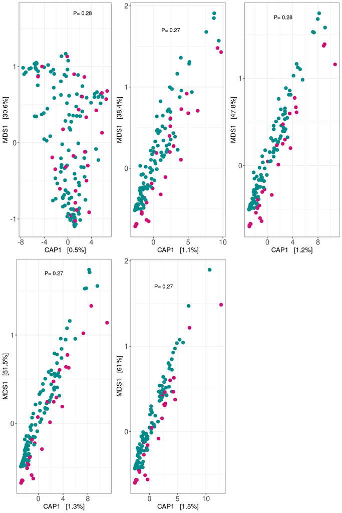

###Differential abundance analysis

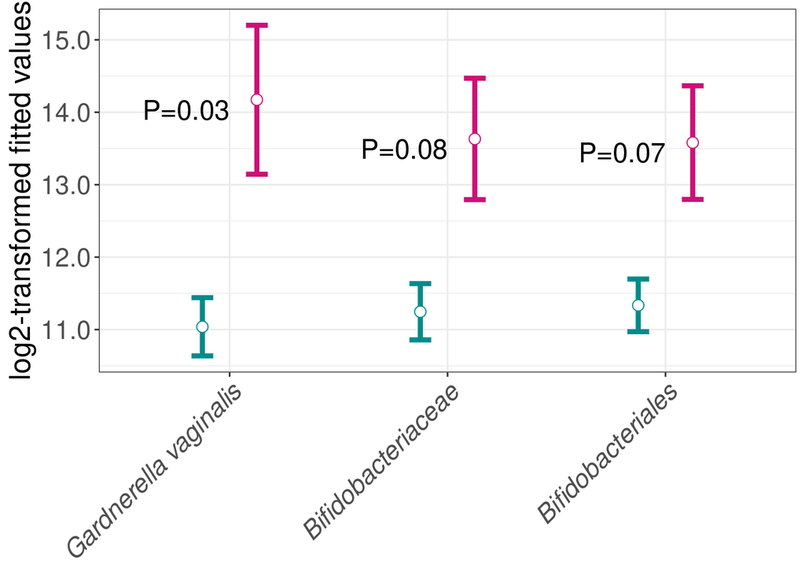

###Composed plots

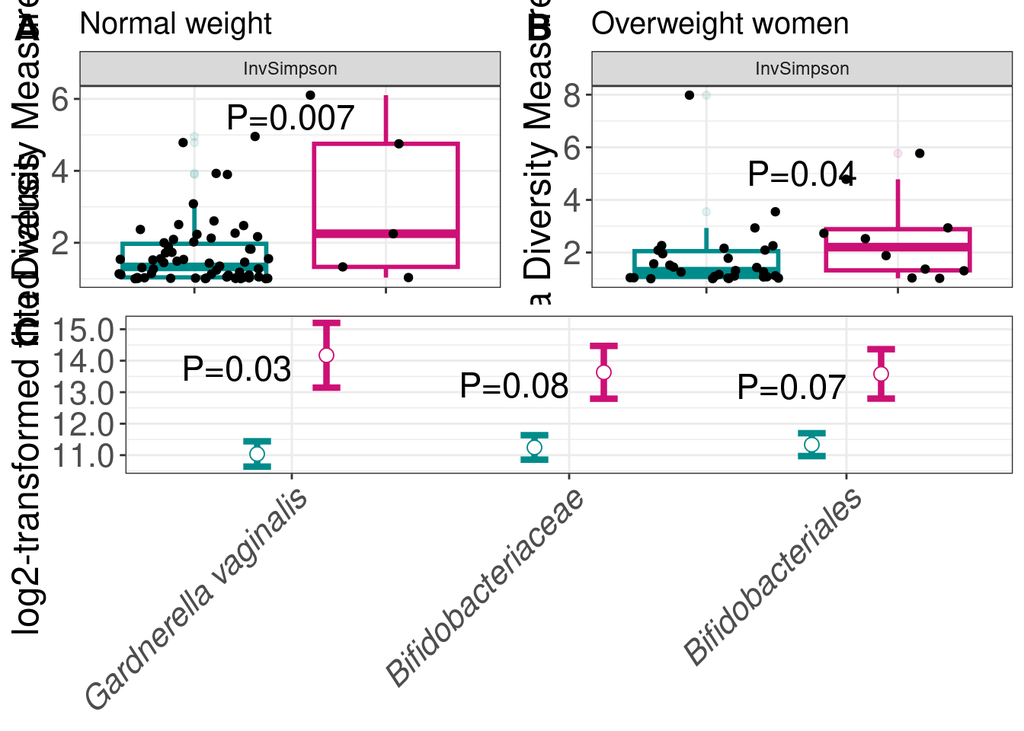

#Vaginal mycobiome

##Premature delivery (PD)

###Description of samples used in this analysis

|  | Premature | Term |
| --- | --- | --- |
| T1D | 17 | 45 |

###Alpha diversity

Green: Premature [<37 weeks]; Orange: Term [37-40 weeks]

|  | LR Chisq | Df | Pr(>Chisq) |
| --- | --- | --- | --- |
| Parity | 0.4995008 | 1 | 0.4797196 |
| GAD | 0.9061438 | 1 | 0.3411397 |
| BMI_Cat | 3.1345257 | 3 | 0.3713454 |
| Parity:GAD | 0.3504074 | 1 | 0.5538826 |
| GAD:BMI_Cat | 0.0602193 | 2 | 0.9703391 |

|  | LR Chisq | Df | Pr(>Chisq) |
| --- | --- | --- | --- |
| BMI_Cat | 3.1897169 | 3 | 0.3632893 |
| GAD | 1.2831787 | 1 | 0.2573088 |
| Parity | 0.7841903 | 1 | 0.3758627 |
| BMI_Cat:GAD | 2.1658640 | 2 | 0.3386013 |
| GAD:Parity | 0.0032647 | 1 | 0.9544359 |

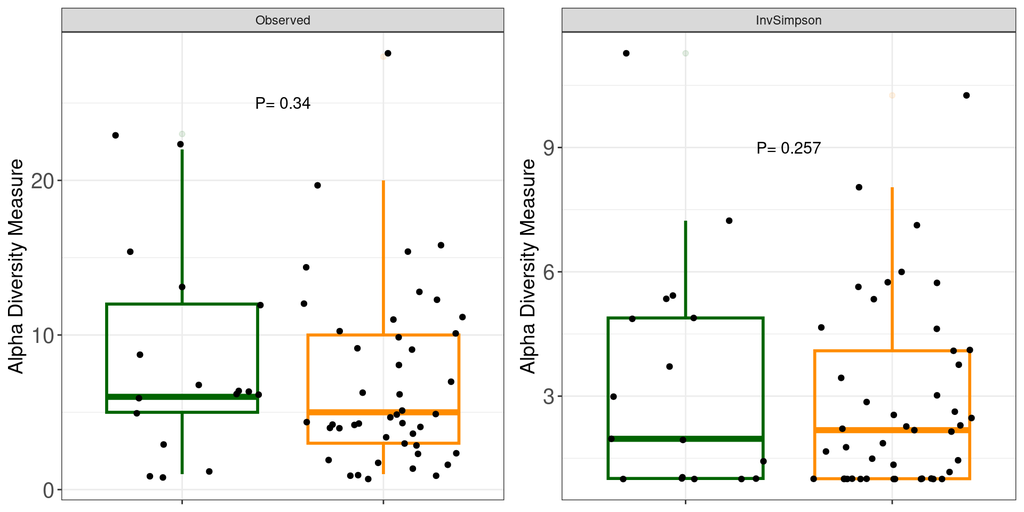

###Beta diversity

Interactions with parity and BMI were tested.

|  | Df | SumOfSqs | R2 | F | Pr(>F) |
| --- | --- | --- | --- | --- | --- |
| Parity | 1 | 0.3195085 | 0.0151420 | 0.8611318 | 0.510 |
| GAD | 1 | 0.3392458 | 0.0160774 | 0.9143274 | 0.468 |
| BMI | 1 | 0.3548729 | 0.0168180 | 0.9564451 | 0.382 |
| Parity:GAD | 1 | 0.1752476 | 0.0083053 | 0.4723232 | 0.978 |
| GAD:BMI | 1 | 0.2471443 | 0.0117126 | 0.6660974 | 0.791 |
| Residual | 53 | 19.6647620 | 0.9319447 | NA | NA |
| Total | 58 | 21.1007812 | 1.0000000 | NA | NA |

|  | Df | SumOfSqs | R2 | F | Pr(>F) |
| --- | --- | --- | --- | --- | --- |
| Parity | 1 | 0.3034087 | 0.0168183 | 0.9557586 | 0.395 |
| GAD | 1 | 0.3470170 | 0.0192356 | 1.0931281 | 0.302 |
| BMI | 1 | 0.2393625 | 0.0132681 | 0.7540087 | 0.602 |
| Parity:GAD | 1 | 0.1227413 | 0.0068037 | 0.3866437 | 0.977 |
| GAD:BMI | 1 | 0.2028336 | 0.0112433 | 0.6389400 | 0.706 |
| Residual | 53 | 16.8250213 | 0.9326310 | NA | NA |
| Total | 58 | 18.0403844 | 1.0000000 | NA | NA |

|  | Df | SumOfSqs | R2 | F | Pr(>F) |
| --- | --- | --- | --- | --- | --- |
| Parity | 1 | 0.2954819 | 0.0166063 | 0.9417446 | 0.407 |
| GAD | 1 | 0.3264897 | 0.0183490 | 1.0405713 | 0.350 |
| BMI | 1 | 0.2227361 | 0.0125179 | 0.7098931 | 0.650 |
| Parity:GAD | 1 | 0.1207915 | 0.0067886 | 0.3849803 | 0.957 |
| GAD:BMI | 1 | 0.1985688 | 0.0111597 | 0.6328684 | 0.739 |
| Residual | 53 | 16.6292846 | 0.9345785 | NA | NA |
| Total | 58 | 17.7933526 | 1.0000000 | NA | NA |

|  | Df | SumOfSqs | R2 | F | Pr(>F) |
| --- | --- | --- | --- | --- | --- |
| Parity | 1 | 0.2018945 | 0.0130140 | 0.7386751 | 0.578 |
| GAD | 1 | 0.2993494 | 0.0192959 | 1.0952352 | 0.319 |
| BMI | 1 | 0.1666325 | 0.0107410 | 0.6096612 | 0.710 |
| Parity:GAD | 1 | 0.1297862 | 0.0083660 | 0.4748512 | 0.822 |
| GAD:BMI | 1 | 0.2300124 | 0.0148265 | 0.8415505 | 0.486 |
| Residual | 53 | 14.4859481 | 0.9337566 | NA | NA |
| Total | 58 | 15.5136231 | 1.0000000 | NA | NA |

|  | Df | SumOfSqs | R2 | F | Pr(>F) |
| --- | --- | --- | --- | --- | --- |
| Parity | 1 | 0.0932551 | 0.0172863 | 0.9360909 | 0.354 |
| GAD | 1 | -0.0185782 | -0.0034438 | -0.1864869 | 0.935 |
| BMI | 1 | 0.0016209 | 0.0003005 | 0.0162705 | 0.815 |
| Parity:GAD | 1 | 0.0012180 | 0.0002258 | 0.0122265 | 0.819 |
| GAD:BMI | 1 | 0.0372689 | 0.0069084 | 0.3741040 | 0.546 |
| Residual | 53 | 5.2799586 | 0.9787228 | NA | NA |
| Total | 58 | 5.3947434 | 1.0000000 | NA | NA |

###Differential abundance analysis

There were no significant differences in specific taxa

##Preeclampsia (PE)

###Description of samples used in this analysis

For analysing the vaginal microbiome of women who had or did not have preeclampsia there are a total of 68 samples for which we have the preeclampsia status. Only samples from women with T1D will be analysed as only women with T1D status had preeclampsia. The samples are distributed as follows:

| Var1 | Freq |
| --- | --- |
| 0 | 57 |
| 1 | 11 |

Since there are no mothers repeated for this dataset, we don’t need to take into account the effect of motherid in any of the analysis.

###Alpha diversity

Cyan: No preeclampsia; Pink: Preeclampsia

|  | LR Chisq | Df | Pr(>Chisq) |
| --- | --- | --- | --- |
| BMI_Cat | 2.6097097 | 3 | 0.4557899 |
| Any.PE | 0.0007989 | 1 | 0.9774503 |
| Parity | 1.1889696 | 1 | 0.2755375 |
| BMI_Cat:Any.PE | 0.5118145 | 2 | 0.7742138 |
| Any.PE:Parity | 3.3482031 | 1 | 0.0672784 |

|  | LR Chisq | Df | Pr(>Chisq) |
| --- | --- | --- | --- |
| BMI_Cat | 0.5269895 | 3 | 0.9129232 |
| Any.PE | 0.5400604 | 1 | 0.4624077 |
| Parity | 0.0591322 | 1 | 0.8078729 |
| BMI_Cat:Any.PE | 3.1031202 | 2 | 0.2119171 |
| Any.PE:Parity | 2.0203386 | 1 | 0.1552045 |

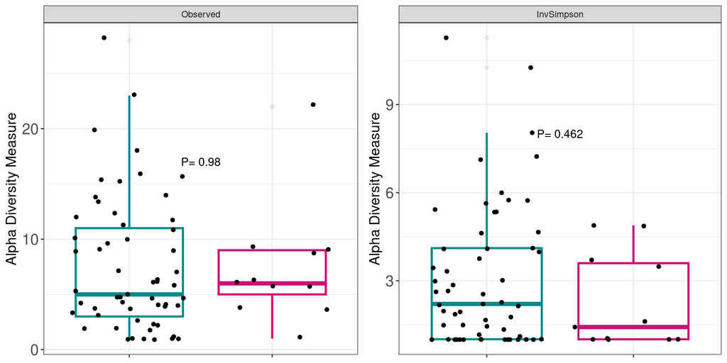

###Beta diversity

|  | Df | SumOfSqs | R2 | F | Pr(>F) |
| --- | --- | --- | --- | --- | --- |
| Parity | 1 | 0.4243988 | 0.0179490 | 1.1356186 | 0.262 |
| Any.PE | 1 | 0.3145902 | 0.0133049 | 0.8417896 | 0.560 |
| BMI | 1 | 0.3783543 | 0.0160017 | 1.0124114 | 0.384 |
| HLA | 2 | 0.6648936 | 0.0281202 | 0.8895708 | 0.555 |
| Parity:Any.PE | 1 | 0.3830962 | 0.0162022 | 1.0251001 | 0.378 |
| Any.PE:BMI | 1 | 0.3843758 | 0.0162563 | 1.0285238 | 0.404 |
| Any.PE:HLA | 2 | 0.5405819 | 0.0228627 | 0.7232524 | 0.792 |
| Residual | 55 | 20.5543767 | 0.8693028 | NA | NA |
| Total | 64 | 23.6446674 | 1.0000000 | NA | NA |

|  | Df | SumOfSqs | R2 | F | Pr(>F) |
| --- | --- | --- | --- | --- | --- |
| Parity | 1 | 0.4306945 | 0.0217753 | 1.3664979 | 0.162 |
| Any.PE | 1 | 0.2444901 | 0.0123611 | 0.7757128 | 0.593 |
| BMI | 1 | 0.2636199 | 0.0133283 | 0.8364073 | 0.504 |
| HLA | 2 | 0.6996345 | 0.0353726 | 1.1098924 | 0.306 |
| Parity:Any.PE | 1 | 0.1274930 | 0.0064459 | 0.4045069 | 0.959 |
| Any.PE:BMI | 1 | 0.2007240 | 0.0101483 | 0.6368527 | 0.741 |
| Any.PE:HLA | 2 | 0.4773930 | 0.0241363 | 0.7573309 | 0.702 |
| Residual | 55 | 17.3349675 | 0.8764322 | NA | NA |
| Total | 64 | 19.7790165 | 1.0000000 | NA | NA |

|  | Df | SumOfSqs | R2 | F | Pr(>F) |
| --- | --- | --- | --- | --- | --- |
| Parity | 1 | 0.4435048 | 0.0228194 | 1.4291184 | 0.137 |
| Any.PE | 1 | 0.2193344 | 0.0112853 | 0.7067675 | 0.661 |
| BMI | 1 | 0.2663440 | 0.0137040 | 0.8582479 | 0.505 |
| HLA | 2 | 0.6758519 | 0.0347742 | 1.0889085 | 0.341 |
| Parity:Any.PE | 1 | 0.1198379 | 0.0061659 | 0.3861571 | 0.936 |
| Any.PE:BMI | 1 | 0.1669084 | 0.0085878 | 0.5378336 | 0.814 |
| Any.PE:HLA | 2 | 0.4752740 | 0.0244540 | 0.7657446 | 0.687 |
| Residual | 55 | 17.0683997 | 0.8782094 | NA | NA |
| Total | 64 | 19.4354550 | 1.0000000 | NA | NA |

|  | Df | SumOfSqs | R2 | F | Pr(>F) |
| --- | --- | --- | --- | --- | --- |
| Parity | 1 | 0.2981680 | 0.0177000 | 1.0964059 | 0.323 |
| Any.PE | 1 | 0.2321400 | 0.0137804 | 0.8536114 | 0.486 |
| BMI | 1 | 0.1737642 | 0.0103151 | 0.6389554 | 0.664 |
| HLA | 2 | 0.6183935 | 0.0367095 | 1.1369601 | 0.290 |
| Parity:Any.PE | 1 | 0.1172200 | 0.0069585 | 0.4310346 | 0.859 |
| Any.PE:BMI | 1 | 0.1335512 | 0.0079280 | 0.4910865 | 0.797 |
| Any.PE:HLA | 2 | 0.3151002 | 0.0187052 | 0.5793341 | 0.848 |
| Residual | 55 | 14.9572712 | 0.8879033 | NA | NA |
| Total | 64 | 16.8456082 | 1.0000000 | NA | NA |

|  | Df | SumOfSqs | R2 | F | Pr(>F) |
| --- | --- | --- | --- | --- | --- |
| Parity | 1 | 0.1500697 | 0.0287454 | 1.7039929 | 0.210 |
| Any.PE | 1 | -0.0121665 | -0.0023305 | -0.1381471 | 0.908 |
| BMI | 1 | -0.0035130 | -0.0006729 | -0.0398892 | 0.856 |
| HLA | 2 | 0.1190387 | 0.0228015 | 0.6758234 | 0.521 |
| Parity:Any.PE | 1 | 0.0180931 | 0.0034657 | 0.2054409 | 0.667 |
| Any.PE:BMI | 1 | 0.0165340 | 0.0031670 | 0.1877380 | 0.670 |
| Any.PE:HLA | 2 | 0.0887746 | 0.0170045 | 0.5040037 | 0.614 |
| Residual | 55 | 4.8438175 | 0.9278192 | NA | NA |
| Total | 64 | 5.2206480 | 1.0000000 | NA | NA |

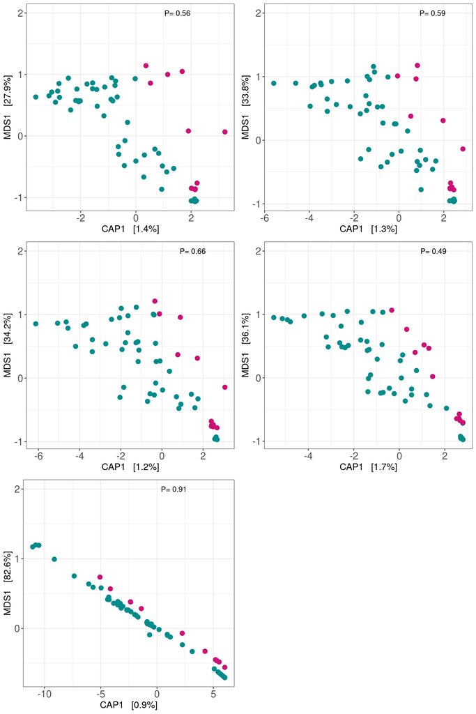

###Differential abundance analysis

There were no significant differences in specific taxa